# Minería de datos: PRA1 - Selección y preparación de un juego de datos

Autor: Oriol Gonzalez Dalmau

Abril 2021

# 1 Problema analítico

- Queremos descubrir cuales son las principales causas de fracaso escolar en las escuelas portuguesas, para esto vamos a estudiar mediante reglas de asociación el caso de dos escuelas portuguesas y las notas de sus alumnos en dos asignaturas, también estudiaremos la correlación de las variables para identificar cuales son las mas influyentes. Mediante el estudio de las componentes principales de nuestro set de datos detemrinaremos cuales son las variables que más variabilidad(información) nos aportan y podremos descartar variables “vacías” ayudándonos a disminuir el coste computacional.

Los principlaes objetivos del problema analítico se basan en crear un estudio de mineria de datos que mediante el uso de modelos supervisados y no supervisados obtenga información y conlusiones sobre los datos. Finalmente, buscaremos crear un arbol de decisón multivariante que permita predecir la nota de los estudiantes según la situación y el entorno en los que se encuentran.

paquetes PRACTICA 2

```r
# install.packages("plyr", dependencies= TRUE)
# install.packages('arulesViz')
# install.packages("xgboost")

library(plyr)
library(arules)
library('arulesViz')
# library('H2O')

require(xgboost)
```

# 2 Juego de datos

fuente: Paulo Cortez, University of Minho, GuimarÃ£es, Portugal, https://archive.ics.uci.edu/ml/datasets/Student+Performance http://www3.dsi.uminho.pt/pcortez

- Tenemos dos juegos de datos en los que cada juego se analizan las notas de los alumnos en portugues y en matemáticas, se incluyen la información sobre dos escuelas en portugal.

Escogemos este set de datos ya que obtiene una muestra representativa al tratar con bastantes registros. Al tener este juego de datos una división entre asignaturas nos resultará más efectivo el uso de modelos no supervisados.

```r
mates <- read.csv(file = "student-mat.csv", sep = ";")

portugues <- read.csv("student-por.csv", sep = ";")

head(portugues)
```

```
##   school sex age address famsize Pstatus Medu Fedu     Mjob     Fjob     reason
## 1     GP   F  18       U     GT3       A    4    4  at_home  teacher     course
## 2     GP   F  17       U     GT3       T    1    1  at_home    other     course
## 3     GP   F  15       U     LE3       T    1    1  at_home    other      other
## 4     GP   F  15       U     GT3       T    4    2   health services       home
## 5     GP   F  16       U     GT3       T    3    3    other    other       home
## 6     GP   M  16       U     LE3       T    4    3 services    other reputation
##   guardian traveltime studytime failures schoolsup famsup paid activities
## 1   mother          2         2        0       yes     no   no         no
## 2   father          1         2        0        no    yes   no         no
## 3   mother          1         2        0       yes     no   no         no
## 4   mother          1         3        0        no    yes   no        yes
## 5   father          1         2        0        no    yes   no         no
## 6   mother          1         2        0        no    yes   no        yes
##   nursery higher internet romantic famrel freetime goout Dalc Walc health
## 1     yes    yes       no       no      4        3     4    1    1      3
## 2      no    yes      yes       no      5        3     3    1    1      3
## 3     yes    yes      yes       no      4        3     2    2    3      3
## 4     yes    yes      yes      yes      3        2     2    1    1      5
## 5     yes    yes       no       no      4        3     2    1    2      5
## 6     yes    yes      yes       no      5        4     2    1    2      5
##   absences G1 G2 G3
## 1        4  0 11 11
## 2        2  9 11 11
## 3        6 12 13 12
## 4        0 14 14 14
## 5        0 11 13 13
## 6        6 12 12 13
```

# 3 Exploración de datos

se tratan 33 columnas 1 school - Escuela (binary: “GP” - Gabriel Pereira or “MS” - Mousinho da Silveira)

2 sex - genero (binary: “F” - female or “M” - male)

3 age - edad (numeric: from 15 to 22)

4 address - residencia del estudiante (binary: “U” - urbana o “R” - rural)

5 famsize - tamaño familiar (binary: “LE3” - 3 o menos personas “GT3” - más de 3 personas)

6 Pstatus - tipo de unidad familiar (binary: “T” - padres juntos o “A” - separados)

7 Medu - Estudios de la madre (numeric: 0 - none, 1 - primary education (4th grade), 2 – 5th to 9th grade, 3 – secondary education or 4 – higher education)

8 Fedu - Estudios del padre (numeric: 0 - none, 1 - primary education (4th grade), 2 – 5th to 9th grade, 3 – secondary education or 4 – higher education)

9 Mjob - Trabajo de la madre (nominal: “teacher”, “health” care related, civil “services” (e.g. administrative or police), “at_home” or “other”)

10 Fjob - Trabajo del padre (nominal: “teacher”, “health” care related, civil “services” (e.g. administrative or police), “at_home” or “other”)

11 reason - razon para escoger la escuela (nominal: close to “home”, school “reputation”, “course” preference or “other”)

12 guardian - Supervisor del alumno (nominal: “mother”, “father” or “other”)

13 traveltime - tiempo de desplazamiento (numeric: 1 - <15 min., 2 - 15 to 30 min., 3 - 30 min. to 1 hour, or 4 - >1 hour)

14 studytime - Horas de estudio semanales (numeric: 1 - <2 hours, 2 - 2 to 5 hours, 3 - 5 to 10 hours, or 4 - >10 hours)

15 failures - numero de clases suspendidas (numeric: n if 1<=n<3, else 4)

16 schoolsup - extra educational support (binary: yes or no)

17 famsup - Soporte familiar para la educación (binary: yes or no)

18 paid - clases de repaso (Math or Portuguese) (binary: yes or no)

19 activities - actividades extraescolares (binary: yes or no)

20 nursery - Atendido en la inferemeria (binary: yes or no)

21 higher - Quiere ir a la universidad (binary: yes or no)

22 internet - Internet en casa (binary: yes or no)

23 romantic - Con pareja (binary: yes or no)

24 famrel - Calidad de la relacion paternofilial (numeric: from 1 - very bad to 5 - excellent)

25 freetime - Tiempo libre en la escuela (numeric: from 1 - very low to 5 - very high)

26 goout - Sale con amigos (numeric: from 1 - very low to 5 - very high)

27 Dalc - Consumo de alcohol semanal (numeric: from 1 - very low to 5 - very high)ç

28 Walc - Consumo de alcohol fin de semana (numeric: from 1 - very low to 5 - very high)

29 health - Estado de salud (numeric: from 1 - very bad to 5 - very good) 30 absences - Absencias en clase (numeric: from 0 to 93)

NOTAS

31 G1 - Primer semestre (numeric: from 0 to 20)

31 G2 - Segundo semestre (numeric: from 0 to 20)

32 G3 - Nota final (numeric: from 0 to 20, output target)

# 4 Acondicionamiento

Debemos comprobar que todos los datos estén sin errores ni valores nulos

comprobamos si hay valores nulos

```r
colSums(is.na(portugues))
```

```
##     school        sex        age    address    famsize    Pstatus       Medu
##          0          0          0          0          0          0          0
##       Fedu       Mjob       Fjob     reason   guardian traveltime  studytime
##          0          0          0          0          0          0          0
##   failures  schoolsup     famsup       paid activities    nursery     higher
##          0          0          0          0          0          0          0
##   internet   romantic     famrel   freetime      goout       Dalc       Walc
##          0          0          0          0          0          0          0
##     health   absences         G1         G2         G3
##          0          0          0          0          0
```

```r
colSums(is.na(mates))
```

```
##     school        sex        age    address    famsize    Pstatus       Medu
##          0          0          0          0          0          0          0
##       Fedu       Mjob       Fjob     reason   guardian traveltime  studytime
##          0          0          0          0          0          0          0
##   failures  schoolsup     famsup       paid activities    nursery     higher
##          0          0          0          0          0          0          0
##   internet   romantic     famrel   freetime      goout       Dalc       Walc
##          0          0          0          0          0          0          0
##     health   absences         G1         G2         G3
##          0          0          0          0          0
```

Comprobamos que no haya datos que no correspondan

```r
summary(mates)
```

```
##     school              sex                 age         address
##  Length:395         Length:395         Min.   :15.0   Length:395
##  Class :character   Class :character   1st Qu.:16.0   Class :character
##  Mode  :character   Mode  :character   Median :17.0   Mode  :character
##                                        Mean   :16.7
##                                        3rd Qu.:18.0
##                                        Max.   :22.0
##    famsize            Pstatus               Medu            Fedu
##  Length:395         Length:395         Min.   :0.000   Min.   :0.000
##  Class :character   Class :character   1st Qu.:2.000   1st Qu.:2.000
##  Mode  :character   Mode  :character   Median :3.000   Median :2.000
##                                        Mean   :2.749   Mean   :2.522
##                                        3rd Qu.:4.000   3rd Qu.:3.000
##                                        Max.   :4.000   Max.   :4.000
##      Mjob               Fjob              reason            guardian
##  Length:395         Length:395         Length:395         Length:395
##  Class :character   Class :character   Class :character   Class :character
##  Mode  :character   Mode  :character   Mode  :character   Mode  :character
##
##
##
##    traveltime      studytime        failures       schoolsup
##  Min.   :1.000   Min.   :1.000   Min.   :0.0000   Length:395
##  1st Qu.:1.000   1st Qu.:1.000   1st Qu.:0.0000   Class :character
##  Median :1.000   Median :2.000   Median :0.0000   Mode  :character
##  Mean   :1.448   Mean   :2.035   Mean   :0.3342
##  3rd Qu.:2.000   3rd Qu.:2.000   3rd Qu.:0.0000
##  Max.   :4.000   Max.   :4.000   Max.   :3.0000
##     famsup              paid            activities          nursery
##  Length:395         Length:395         Length:395         Length:395
##  Class :character   Class :character   Class :character   Class :character
##  Mode  :character   Mode  :character   Mode  :character   Mode  :character
##
##
##
##     higher            internet           romantic             famrel
##  Length:395         Length:395         Length:395         Min.   :1.000
##  Class :character   Class :character   Class :character   1st Qu.:4.000
##  Mode  :character   Mode  :character   Mode  :character   Median :4.000
##                                                           Mean   :3.944
```

[output cut: 8 more lines]

```
##  Max.   :5.000   Max.   :5.000   Max.   :5.000   Max.   :5.000
##      health         absences            G1              G2
##  Min.   :1.000   Min.   : 0.000   Min.   : 3.00   Min.   : 0.00
##  1st Qu.:3.000   1st Qu.: 0.000   1st Qu.: 8.00   1st Qu.: 9.00
##  Median :4.000   Median : 4.000   Median :11.00   Median :11.00
##  Mean   :3.554   Mean   : 5.709   Mean   :10.91   Mean   :10.71
##  3rd Qu.:5.000   3rd Qu.: 8.000   3rd Qu.:13.00   3rd Qu.:13.00
##  Max.   :5.000   Max.   :75.000   Max.   :19.00   Max.   :19.00
##        G3
##  Min.   : 0.00
##  1st Qu.: 8.00
##  Median :11.00
##  Mean   :10.42
##  3rd Qu.:14.00
##  Max.   :20.00
```

```r
summary(portugues)
```

```
##     school              sex                 age          address
##  Length:649         Length:649         Min.   :15.00   Length:649
##  Class :character   Class :character   1st Qu.:16.00   Class :character
##  Mode  :character   Mode  :character   Median :17.00   Mode  :character
##                                        Mean   :16.74
##                                        3rd Qu.:18.00
##                                        Max.   :22.00
##    famsize            Pstatus               Medu            Fedu
##  Length:649         Length:649         Min.   :0.000   Min.   :0.000
##  Class :character   Class :character   1st Qu.:2.000   1st Qu.:1.000
##  Mode  :character   Mode  :character   Median :2.000   Median :2.000
##                                        Mean   :2.515   Mean   :2.307
##                                        3rd Qu.:4.000   3rd Qu.:3.000
##                                        Max.   :4.000   Max.   :4.000
##      Mjob               Fjob              reason            guardian
##  Length:649         Length:649         Length:649         Length:649
##  Class :character   Class :character   Class :character   Class :character
##  Mode  :character   Mode  :character   Mode  :character   Mode  :character
##
##
##
##    traveltime      studytime        failures       schoolsup
##  Min.   :1.000   Min.   :1.000   Min.   :0.0000   Length:649
##  1st Qu.:1.000   1st Qu.:1.000   1st Qu.:0.0000   Class :character
##  Median :1.000   Median :2.000   Median :0.0000   Mode  :character
##  Mean   :1.569   Mean   :1.931   Mean   :0.2219
##  3rd Qu.:2.000   3rd Qu.:2.000   3rd Qu.:0.0000
##  Max.   :4.000   Max.   :4.000   Max.   :3.0000
##     famsup              paid            activities          nursery
##  Length:649         Length:649         Length:649         Length:649
##  Class :character   Class :character   Class :character   Class :character
##  Mode  :character   Mode  :character   Mode  :character   Mode  :character
##
##
##
##     higher            internet           romantic             famrel
##  Length:649         Length:649         Length:649         Min.   :1.000
##  Class :character   Class :character   Class :character   1st Qu.:4.000
##  Mode  :character   Mode  :character   Mode  :character   Median :4.000
##                                                           Mean   :3.931
##                                                           3rd Qu.:5.000
##                                                           Max.   :5.000
##     freetime        goout            Dalc            Walc          health
##  Min.   :1.00   Min.   :1.000   Min.   :1.000   Min.   :1.00   Min.   :1.000
##  1st Qu.:3.00   1st Qu.:2.000   1st Qu.:1.000   1st Qu.:1.00   1st Qu.:2.000
##  Median :3.00   Median :3.000   Median :1.000   Median :2.00   Median :4.000
##  Mean   :3.18   Mean   :3.185   Mean   :1.502   Mean   :2.28   Mean   :3.536
##  3rd Qu.:4.00   3rd Qu.:4.000   3rd Qu.:2.000   3rd Qu.:3.00   3rd Qu.:5.000
##  Max.   :5.00   Max.   :5.000   Max.   :5.000   Max.   :5.00   Max.   :5.000
##     absences            G1             G2              G3
##  Min.   : 0.000   Min.   : 0.0   Min.   : 0.00   Min.   : 0.00
##  1st Qu.: 0.000   1st Qu.:10.0   1st Qu.:10.00   1st Qu.:10.00
##  Median : 2.000   Median :11.0   Median :11.00   Median :12.00
##  Mean   : 3.659   Mean   :11.4   Mean   :11.57   Mean   :11.91
##  3rd Qu.: 6.000   3rd Qu.:13.0   3rd Qu.:13.00   3rd Qu.:14.00
##  Max.   :32.000   Max.   :19.0   Max.   :19.00   Max.   :19.00
```

Gracias a la información adjunta en el repositorio de los datos, sabemos que exiten alumnos duplicados, esto es debido a que todos los alumnos que hacen matemáticas también estudian portugues, pero no todos los alumnos hacen matemáticas. Debemos tener en cuenta esto para realizar los modelos supervisados y no crear overfitting con estudiantes duplicados en el set de datos de testeo.

Los datos parecen correctos, así que vamos a proceder fatorizando las variables.

# 5 Discretización

Pasamos las variables que no son numericas a un factor numérico, este proceso nos perimte computar el análisis de componentes princiaples entre otras.

```r
names(portugues)
```

```
##  [1] "school"     "sex"        "age"        "address"    "famsize"
##  [6] "Pstatus"    "Medu"       "Fedu"       "Mjob"       "Fjob"
## [11] "reason"     "guardian"   "traveltime" "studytime"  "failures"
## [16] "schoolsup"  "famsup"     "paid"       "activities" "nursery"
## [21] "higher"     "internet"   "romantic"   "famrel"     "freetime"
## [26] "goout"      "Dalc"       "Walc"       "health"     "absences"
## [31] "G1"         "G2"         "G3"
```

```r
copia_portugues <- portugues

variables <- names(portugues)
```

De las variables, nos interesa pasar a numerico las que estan en fromato character. Es decir, (por orden): 1,2,4,5,6,9,10,11,12,16,17,18,19,20,21,22,23. “school” “sex” “address” “famsize” “Pstatus” “Mjob” “Fjob” “reason” “guardian” “schoolsup” “famsup” “paid” “activities” “nursery” “higher” “internet” “romantic”

```r
variables = variables[c(1,2,4,5,6,9,10,11,12,16,17,18,19,20,21,22,23)]
```

```r
# pasamos a factor las variables de los alumnos de portugues
for (i in variables){
  portugues[,i] = as.numeric(as.factor(portugues[,i]))
}

# pasamos a factor las variables de los alumnos de mates
for (i in variables){
  mates[,i] = as.numeric(as.factor(mates[,i]))
}

summary(mates)
```

```
##      school           sex             age          address         famsize
##  Min.   :1.000   Min.   :1.000   Min.   :15.0   Min.   :1.000   Min.   :1.000
##  1st Qu.:1.000   1st Qu.:1.000   1st Qu.:16.0   1st Qu.:2.000   1st Qu.:1.000
##  Median :1.000   Median :1.000   Median :17.0   Median :2.000   Median :1.000
##  Mean   :1.116   Mean   :1.473   Mean   :16.7   Mean   :1.777   Mean   :1.289
##  3rd Qu.:1.000   3rd Qu.:2.000   3rd Qu.:18.0   3rd Qu.:2.000   3rd Qu.:2.000
##  Max.   :2.000   Max.   :2.000   Max.   :22.0   Max.   :2.000   Max.   :2.000
##     Pstatus           Medu            Fedu            Mjob           Fjob
##  Min.   :1.000   Min.   :0.000   Min.   :0.000   Min.   :1.00   Min.   :1.000
##  1st Qu.:2.000   1st Qu.:2.000   1st Qu.:2.000   1st Qu.:3.00   1st Qu.:3.000
##  Median :2.000   Median :3.000   Median :2.000   Median :3.00   Median :3.000
##  Mean   :1.896   Mean   :2.749   Mean   :2.522   Mean   :3.17   Mean   :3.281
##  3rd Qu.:2.000   3rd Qu.:4.000   3rd Qu.:3.000   3rd Qu.:4.00   3rd Qu.:4.000
##  Max.   :2.000   Max.   :4.000   Max.   :4.000   Max.   :5.00   Max.   :5.000
##      reason         guardian       traveltime      studytime
##  Min.   :1.000   Min.   :1.000   Min.   :1.000   Min.   :1.000
##  1st Qu.:1.000   1st Qu.:2.000   1st Qu.:1.000   1st Qu.:1.000
##  Median :2.000   Median :2.000   Median :1.000   Median :2.000
##  Mean   :2.256   Mean   :1.853   Mean   :1.448   Mean   :2.035
##  3rd Qu.:4.000   3rd Qu.:2.000   3rd Qu.:2.000   3rd Qu.:2.000
##  Max.   :4.000   Max.   :3.000   Max.   :4.000   Max.   :4.000
##     failures        schoolsup         famsup           paid
##  Min.   :0.0000   Min.   :1.000   Min.   :1.000   Min.   :1.000
##  1st Qu.:0.0000   1st Qu.:1.000   1st Qu.:1.000   1st Qu.:1.000
##  Median :0.0000   Median :1.000   Median :2.000   Median :1.000
##  Mean   :0.3342   Mean   :1.129   Mean   :1.613   Mean   :1.458
##  3rd Qu.:0.0000   3rd Qu.:1.000   3rd Qu.:2.000   3rd Qu.:2.000
##  Max.   :3.0000   Max.   :2.000   Max.   :2.000   Max.   :2.000
##    activities       nursery          higher         internet
##  Min.   :1.000   Min.   :1.000   Min.   :1.000   Min.   :1.000
##  1st Qu.:1.000   1st Qu.:2.000   1st Qu.:2.000   1st Qu.:2.000
##  Median :2.000   Median :2.000   Median :2.000   Median :2.000
##  Mean   :1.509   Mean   :1.795   Mean   :1.949   Mean   :1.833
##  3rd Qu.:2.000   3rd Qu.:2.000   3rd Qu.:2.000   3rd Qu.:2.000
##  Max.   :2.000   Max.   :2.000   Max.   :2.000   Max.   :2.000
##     romantic         famrel         freetime         goout
##  Min.   :1.000   Min.   :1.000   Min.   :1.000   Min.   :1.000
##  1st Qu.:1.000   1st Qu.:4.000   1st Qu.:3.000   1st Qu.:2.000
##  Median :1.000   Median :4.000   Median :3.000   Median :3.000
##  Mean   :1.334   Mean   :3.944   Mean   :3.235   Mean   :3.109
##  3rd Qu.:2.000   3rd Qu.:5.000   3rd Qu.:4.000   3rd Qu.:4.000
##  Max.   :2.000   Max.   :5.000   Max.   :5.000   Max.   :5.000
##       Dalc            Walc           health         absences
##  Min.   :1.000   Min.   :1.000   Min.   :1.000   Min.   : 0.000
##  1st Qu.:1.000   1st Qu.:1.000   1st Qu.:3.000   1st Qu.: 0.000
##  Median :1.000   Median :2.000   Median :4.000   Median : 4.000
##  Mean   :1.481   Mean   :2.291   Mean   :3.554   Mean   : 5.709
##  3rd Qu.:2.000   3rd Qu.:3.000   3rd Qu.:5.000   3rd Qu.: 8.000
##  Max.   :5.000   Max.   :5.000   Max.   :5.000   Max.   :75.000
##        G1              G2              G3
##  Min.   : 3.00   Min.   : 0.00   Min.   : 0.00
##  1st Qu.: 8.00   1st Qu.: 9.00   1st Qu.: 8.00
##  Median :11.00   Median :11.00   Median :11.00
##  Mean   :10.91   Mean   :10.71   Mean   :10.42
##  3rd Qu.:13.00   3rd Qu.:13.00   3rd Qu.:14.00
##  Max.   :19.00   Max.   :19.00   Max.   :20.00
```

# 6 Análisis de los componentes principales

Para empezar con el análisis de los componentes principales, y debido a que tenemos diversas medidas con un rango de valores dispersos, vamos a proceder con el escalado de los datos de la matriz, realizaremos este proceso por las dos matrices portugues y mates.

```r
portugues_scale <- scale(portugues)
```

Vamos a estudiar la matriz de covarianza de los datos

1. Creamos la matriz de covarianza
2. Eliminamos la diagonal dado que nuestros datos están normalizados, todos los términos de la diagonal principal son 1
3. Localizamos las covarianzas mas grandes en valor absoluto.

Obviamos g1, g2, g3, que son las notas, ya que al formarse g3 mediante g1 y g2 la covarianza se dispara.

```r
cov_port <- cov(portugues_scale) # creamos la matriz de covarianza

# Restamos la diagonal simetrica
CWsABS <-abs( cov_port - diag(33) )# ya que hay 33 variables

# ordenamos los valores de forma decreciente
x <- order(CWsABS, decreasing = TRUE)

# como los valores estan duplicados(matriz simetrica) escogemos
# cada dos, a partir de la 7 porque de la 1 a la 6 son las covarianzas
# de g1, g2, g3
posiciones <- x[c(7,9,11,13,15,17,19,21,23,25)]

for (i in posiciones){
  print(which(CWsABS == CWsABS[i], arr.ind = T))

   }
```

```
##      row col
## Fedu   8   7
## Medu   7   8
##      row col
## Walc  28  27
## Dalc  27  28
##      row col
## Mjob   9   7
## Medu   7   9
##          row col
## G3        33  15
## failures  15  33
##       row col
## Walc   28  26
## goout  26  28
##          row col
## G2        32  15
## failures  15  32
##          row col
## G1        31  15
## failures  15  31
##         row col
## address   4   1
## school    1   4
##        row col
## G1      31  21
## higher  21  31
##          row col
## goout     26  25
## freetime  25  26
```

Despues de las notas, podemos ver las correlaciones que existen entre variables, más allá de las mismas notas, lo segundo que mas afecta a la nota final son failures(clases suspendidas previamente) y higher(si los alumnos quieren ir a la universidad)

Realizamos mediante prcomp el análisis de los componentes principales, y estudiaremos la variabilidad acumulada

```r
portugues.pca <- prcomp(cov_port, scale. = FALSE, center = FALSE)
summary(portugues.pca)
```

```
## Importance of components:
##                           PC1    PC2     PC3     PC4     PC5     PC6    PC7
## Standard deviation     0.7785 0.4552 0.31420 0.29740 0.25229 0.23159 0.2241
## Proportion of Variance 0.3668 0.1254 0.05974 0.05352 0.03852 0.03245 0.0304
## Cumulative Proportion  0.3668 0.4921 0.55185 0.60537 0.64389 0.67634 0.7067
##                            PC8    PC9    PC10    PC11    PC12    PC13    PC14
## Standard deviation     0.22336 0.2065 0.18909 0.18231 0.17681 0.17082 0.16488
## Proportion of Variance 0.03019 0.0258 0.02163 0.02011 0.01892 0.01766 0.01645
## Cumulative Proportion  0.73693 0.7627 0.78436 0.80447 0.82339 0.84105 0.85749
##                          PC15    PC16   PC17    PC18    PC19    PC20    PC21
## Standard deviation     0.1611 0.15416 0.1515 0.14449 0.13526 0.12779 0.12390
## Proportion of Variance 0.0157 0.01438 0.0139 0.01263 0.01107 0.00988 0.00929
## Cumulative Proportion  0.8732 0.88758 0.9015 0.91410 0.92518 0.93506 0.94435
##                           PC22    PC23    PC24    PC25    PC26    PC27    PC28
## Standard deviation     0.11861 0.11660 0.11341 0.10958 0.10103 0.08994 0.08557
## Proportion of Variance 0.00851 0.00823 0.00778 0.00727 0.00618 0.00489 0.00443
## Cumulative Proportion  0.95286 0.96109 0.96887 0.97614 0.98231 0.98721 0.99164
##                           PC29    PC30    PC31    PC32    PC33
## Standard deviation     0.08303 0.05837 0.04974 0.02969 0.01276
## Proportion of Variance 0.00417 0.00206 0.00150 0.00053 0.00010
## Cumulative Proportion  0.99581 0.99787 0.99937 0.99990 1.00000
```

```r
portugues.pca$rotation[,1]
```

```
##       school          sex          age      address      famsize      Pstatus
## -0.215417217 -0.053650000 -0.146881295  0.149246952  0.011833074 -0.005058654
##         Medu         Fedu         Mjob         Fjob       reason     guardian
##  0.254757032  0.222042862  0.176644969  0.084447083  0.118502208 -0.085826817
##   traveltime    studytime     failures    schoolsup       famsup         paid
## -0.161364347  0.173351181 -0.255234424  0.020484510  0.066740449 -0.006048405
##   activities      nursery       higher     internet     romantic       famrel
##  0.055225907  0.051363932  0.245808373  0.139819471 -0.071899724  0.048615442
##     freetime        goout         Dalc         Walc       health     absences
## -0.075851485 -0.078733908 -0.147601391 -0.132690230 -0.030606735 -0.075885069
##           G1           G2           G3
##  0.389593811  0.392500688  0.386700630
```

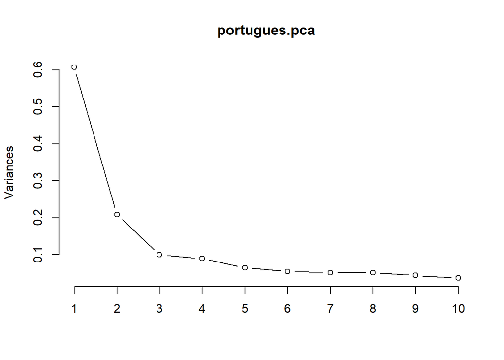

```r
plot(portugues.pca, type = "l")
```

Así pues, obtenemos que con las 3 componentes principales explicamos el 55.18% de la variabilidad de los datos. En las componentes principales, de forma analoga con la matriz de covarianza, obtenemos que las variables con mas importancia son las notas g1, g2, g3, seguido de failures, la educación de la madre, si quieren ir a la universidad, la educación del padre y la escuela(lo que podría indicar que los datos estan sesgados de alguna manera, o que los profesores son mas buenos en una que otra)

Obviamos g1, g2, g3, que son las notas, ya que al formarse g3 mediante g1 y g2 la covarianza se dispara.

```r
mates_scale <- scale(mates)
cov_mates <- cov(mates_scale) # creamos la matriz de covarianza

# Restamos la diagonal simetrica
cov_ABS <-abs( cov_mates - diag(33) )# ya que hay 33 variables

# ordenamos los valores de forma decreciente
x <- order(cov_ABS, decreasing = TRUE)

# como los valores estan duplicados(matriz simetrica) escogemos
# cada dos, a partir de la 7 porque de la 1 a la 6 son las covarianzas
# de g1, g2, g3
posiciones <- x[c(7,9,11,13,15,17,19,21,23,25,27,29,31)]

for (i in posiciones){
  print(which(cov_ABS == cov_ABS[i], arr.ind = T))

   }
```

```
##      row col
## Walc  28  27
## Dalc  27  28
##      row col
## Fedu   8   7
## Medu   7   8
##      row col
## Mjob   9   7
## Medu   7   9
##       row col
## Walc   28  26
## goout  26  28
##        row col
## age      3   1
## school   1   3
##          row col
## G3        33  15
## failures  15  33
##          row col
## G2        32  15
## failures  15  32
##          row col
## G1        31  15
## failures  15  31
##            row col
## traveltime  13   4
## address      4  13
##           row col
## studytime  14   2
## sex         2  14
##          row col
## higher    21  15
## failures  15  21
##        row col
## paid    18  17
## famsup  17  18
##          row col
## guardian  12   3
## age        3  12
```

Despues de las notas, podemos ver las correlaciones que existen entre variables, más allá de las mismas notas, lo que mas afecta a la nota final de mates son failures(clases suspendidas previamente) de nuevo.

Realizamos mediante prcomp el análisis de los componentes principales, y estudiaremos la variabilidad acumulada

```r
mates.pca <- prcomp(cov_mates, scale. = FALSE, center = FALSE)
summary(mates.pca)
```

```
## Importance of components:
##                           PC1    PC2     PC3     PC4     PC5    PC6     PC7
## Standard deviation     0.6847 0.4489 0.39405 0.31461 0.26953 0.2531 0.24717
## Proportion of Variance 0.2934 0.1261 0.09718 0.06195 0.04547 0.0401 0.03824
## Cumulative Proportion  0.2934 0.4195 0.51666 0.57860 0.62407 0.6642 0.70241
##                            PC8     PC9    PC10    PC11   PC12    PC13    PC14
## Standard deviation     0.21960 0.21133 0.19572 0.18974 0.1801 0.17121 0.16896
## Proportion of Variance 0.03018 0.02795 0.02397 0.02253 0.0203 0.01835 0.01787
## Cumulative Proportion  0.73259 0.76054 0.78451 0.80704 0.8274 0.84569 0.86356
##                           PC15    PC16    PC17    PC18    PC19    PC20    PC21
## Standard deviation     0.16067 0.14889 0.14167 0.14096 0.13463 0.12669 0.12453
## Proportion of Variance 0.01616 0.01387 0.01256 0.01244 0.01134 0.01005 0.00971
## Cumulative Proportion  0.87972 0.89359 0.90615 0.91859 0.92993 0.93997 0.94968
##                          PC22    PC23    PC24    PC25    PC26    PC27    PC28
## Standard deviation     0.1131 0.11123 0.10521 0.09890 0.09459 0.08749 0.08100
## Proportion of Variance 0.0080 0.00774 0.00693 0.00612 0.00560 0.00479 0.00411
## Cumulative Proportion  0.9577 0.96543 0.97236 0.97848 0.98408 0.98887 0.99297
##                           PC29    PC30    PC31    PC32    PC33
## Standard deviation     0.07027 0.05338 0.04916 0.02891 0.01372
## Proportion of Variance 0.00309 0.00178 0.00151 0.00052 0.00012
## Cumulative Proportion  0.99606 0.99785 0.99936 0.99988 1.00000
```

```r
mates.pca$rotation[,1]
```

```
##      school         sex         age     address     famsize     Pstatus
## -0.13597173 -0.01512137 -0.19933182  0.13934614  0.00506002 -0.03663549
##        Medu        Fedu        Mjob        Fjob      reason    guardian
##  0.27437633  0.23800134  0.15422899  0.04849922  0.11262364 -0.08792786
##  traveltime   studytime    failures   schoolsup      famsup        paid
## -0.16417492  0.15055610 -0.30054390 -0.00639615  0.08013352  0.13000282
##  activities     nursery      higher    internet    romantic      famrel
##  0.07741243  0.11670891  0.20534965  0.13006238 -0.06240764  0.02153939
##    freetime       goout        Dalc        Walc      health    absences
## -0.04653171 -0.11390341 -0.13394525 -0.15740485 -0.05966967 -0.02074866
##          G1          G2          G3
##  0.36807006  0.39295325  0.37971142
```

```r
mates.pca$rotation[,2]
```

```
##       school          sex          age      address      famsize      Pstatus
## -0.071657755 -0.387378517 -0.073723407 -0.003774274 -0.131441810  0.034043069
##         Medu         Fedu         Mjob         Fjob       reason     guardian
## -0.173971456 -0.139240335 -0.219024457 -0.151484362  0.069241822  0.024278044
##   traveltime    studytime     failures    schoolsup       famsup         paid
## -0.054719243  0.260828874 -0.038395786  0.159156389  0.111365897  0.021788490
##   activities      nursery       higher     internet     romantic       famrel
## -0.030746199  0.021716882  0.078382147 -0.102157687  0.019208498 -0.008569247
##     freetime        goout         Dalc         Walc       health     absences
## -0.268604054 -0.268528070 -0.414573592 -0.422713915 -0.089088104 -0.082954743
##           G1           G2           G3
## -0.126218331 -0.134265394 -0.149074651
```

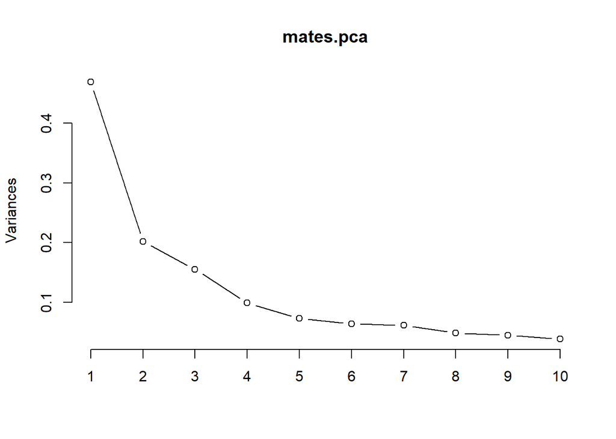

```r
plot(mates.pca, type = "l")
```

```r
#for (i in c(1:32)){ s = i+1 biplot(portugues.pca, choices = i:s, scale = 0 )}portugues.pca$rotation[,32]
```

Así pues, obtenemos que con las 3 componentes principales explicamos el 51.66% de la variabilidad de los datos. En la primera componente principal, de forma analoga con la matriz de covarianza, obtenemos que las variables con más importancia son las notas g1, g2, g3, seguido de failures (0.30), la educación de la madre(0.27), la educación del padre (0.23) y si quieren ir a la universidad(0.20).

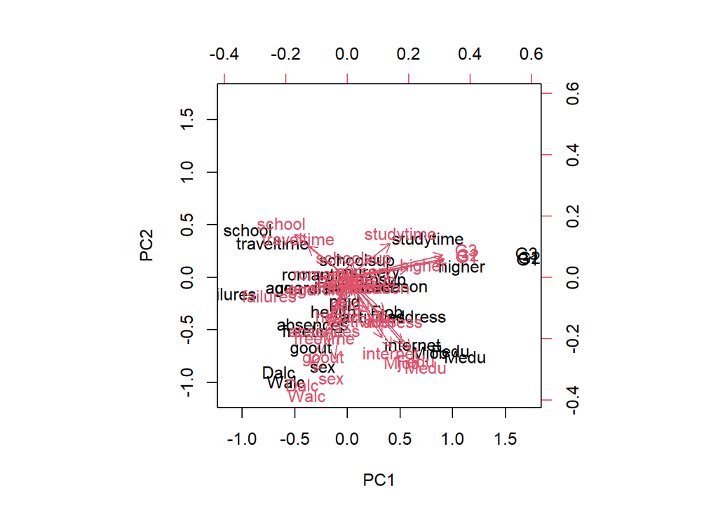

```r
biplot(portugues.pca, choices = 1:2, scale = 0, )
```

Como vemos en el gráfico anterior, todas las variables estan muy dispersas y no existe una componente principal que explique la mayoría.

Podemos concluir explicando que el análisis de las componentes principales es un método para reducir la dimensionalidad, por ejemplo, si encontramos oportuno, podríamos coger las 11 primeras componentes principales para mates y explicar el 80.7% de variabilidad del dataframe original, aunque en nuestro caso, recordamos que el objetivo es predecir g3, así que creemos que como más atributos/variables un modelo de mejor calidad predictiva será generado.

# 7 PRACTICA 2

## 7.1 Modelo no supervisado

Clustering de los datos, con el método de los centroides k-means.

0- Cargamos las librerias

```r
library(cluster)
```

0.1- Para este análisis, y conociendo que existen dos datasets de estudio, aprovecharemos para compararlos entre ellos, creando los modelos para los datos de las dos asignaturas. (Usaremos los datos escalados)

1- PORTUGUESE

```r
nrow(portugues_scale)
```

```
## [1] 649
```

```r
nrow(portugues)
```

```
## [1] 649
```

### 7.1.1 Creación de un modelo no supervisado.

1.1- A continuación vamos a aplicar el algoritmo kmeans.

Como inicialmente no conocemos el número óptimo de clústers, probamos con varios valores

```r
# Calculamos las distancias con daisy.

d <- daisy(portugues_scale)
resultados <- rep(0, 10)
for (i in c(2,3,4,5,6,7,8,9,10))
{
  fit           <- kmeans(portugues_scale, i)
  y_cluster     <- fit$cluster
  sk            <- silhouette(y_cluster, d)
  resultados[i] <- mean(sk[,3])
}
```

Mostramos en un gráfico los valores de las siluetas medias de cada prueba para comprobar que número de clústers es el mejor.

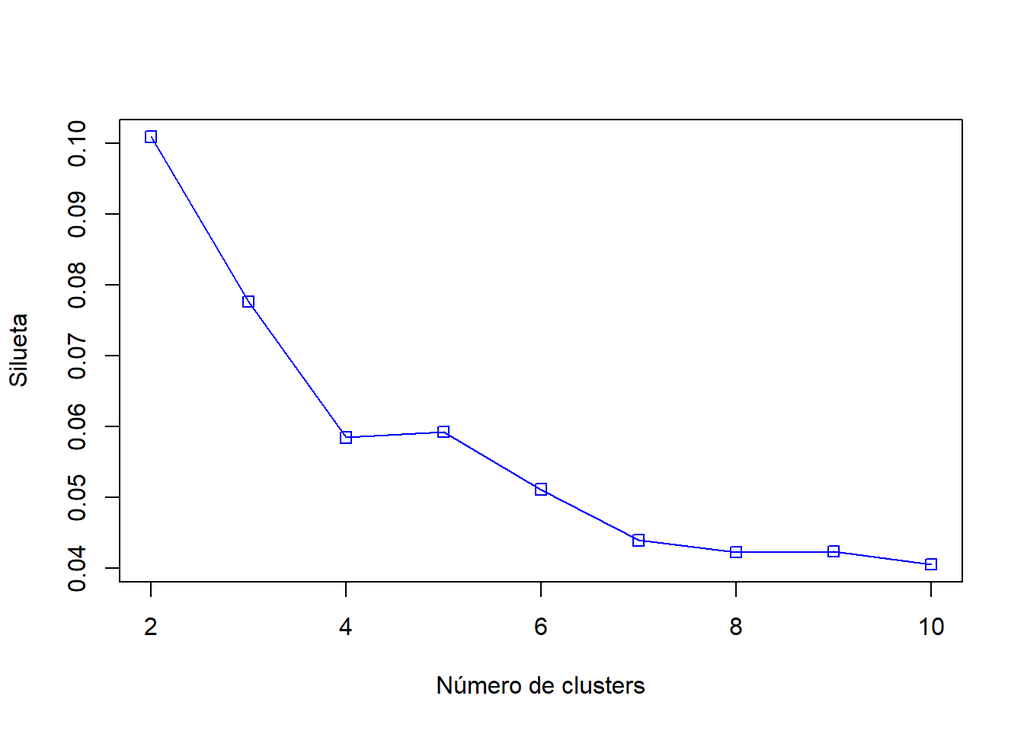

```r
plot(2:10,resultados[2:10],type="o",col="blue",pch=0,xlab="Número de clusters",ylab="Silueta")
```

Tras probar diferentes veces, el numero idóneo se encuentra entre 2, 3 y 4 clusters.

Utilizamos el método Elbow:

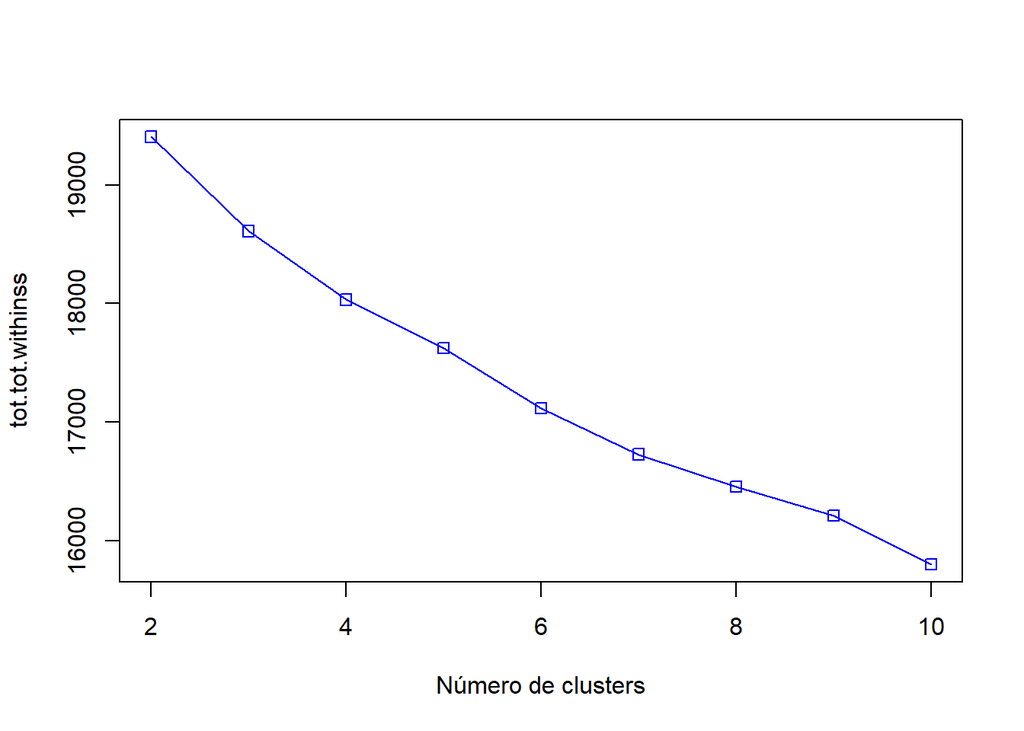

```r
resultados <- rep(0, 10)
for (i in c(2,3,4,5,6,7,8,9,10))
{
  fit           <- kmeans(portugues_scale, i)
  resultados[i] <- fit$tot.withinss
}
plot(2:10,resultados[2:10],type="o",col="blue",pch=0,xlab="Número de clusters",ylab="tot.tot.withinss")
```

Parece ser que los datos no responden correctamente a este método de clustering. Continuamos probando los diferentes clusters, luego, probaremos de nuevo reformulando el modelo siguiendo el análisis previo de las PCA.

- Generamos el modelo con 2 clusters

```r
  fit           <- kmeans(portugues_scale, 2)
  y_cluster     <- fit$cluster
```

Para visualizar los clústers podemos usar la función clusplot.

Vemos la agrupación con 2 clústers

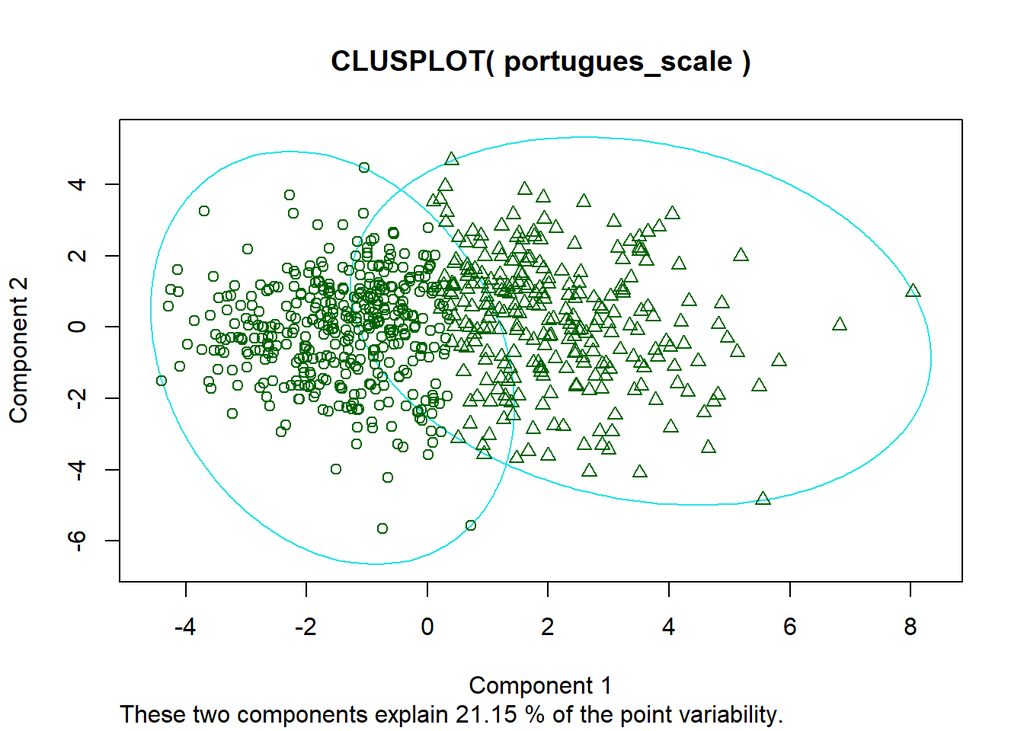

```r
clusplot(portugues_scale, y_cluster)
```

Las agrupaciones son poco claras y se enmarcan una dentro de la otra.

- Generamos el modelo con 7 clusters

```r
  fit           <- kmeans(portugues_scale,7)
  y_cluster     <- fit$cluster
```

Para visualizar los clústers podemos usar la función clusplot.

Vemos la agrupación con 7 clústers

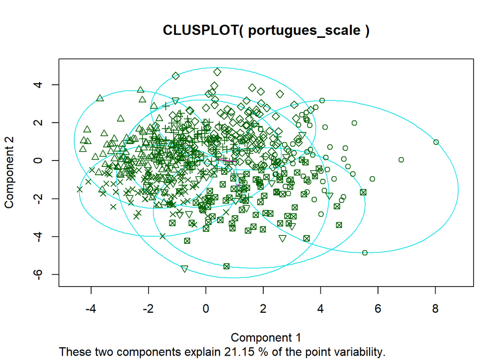

```r
clusplot(portugues_scale, y_cluster)
```

**Para intentar generar un mejor modelo, procedemos a crear un dataset con las variables más importantes del PCA:**

```r
sort(abs(portugues.pca$rotation[,1]),decreasing = TRUE)*1
```

```
##          G2          G1          G3    failures        Medu      higher
## 0.392500688 0.389593811 0.386700630 0.255234424 0.254757032 0.245808373
##        Fedu      school        Mjob   studytime  traveltime     address
## 0.222042862 0.215417217 0.176644969 0.173351181 0.161364347 0.149246952
##        Dalc         age    internet        Walc      reason    guardian
## 0.147601391 0.146881295 0.139819471 0.132690230 0.118502208 0.085826817
##        Fjob       goout    absences    freetime    romantic      famsup
## 0.084447083 0.078733908 0.075885069 0.075851485 0.071899724 0.066740449
##  activities         sex     nursery      famrel      health   schoolsup
## 0.055225907 0.053650000 0.051363932 0.048615442 0.030606735 0.020484510
##     famsize        paid     Pstatus
## 0.011833074 0.006048405 0.005058654
```

```r
portugues_2 <- portugues[c(1,7,8,15,21,33)]
portugues_2_scale <- scale(portugues_2)
head(portugues_2)
```

```
##   school Medu Fedu failures higher G3
## 1      1    4    4        0      2 11
## 2      1    1    1        0      2 11
## 3      1    1    1        0      2 12
## 4      1    4    2        0      2 14
## 5      1    3    3        0      2 13
## 6      1    4    3        0      2 13
```

Volvemos a crear los clusters con el nuevo DF

```r
# Calculamos las distancias con daisy.
d <- daisy(portugues_2_scale)
for (i in c(2,3,4,5,6,7,8,9,10))
{
  fit           <- kmeans(portugues_2_scale, i)
  y_cluster     <- fit$cluster
  sk            <- silhouette(y_cluster, d)
  resultados[i] <- mean(sk[,3])
}
```

Representamos en un gráfica los valores de las siluetas media de cada prueba para comprobar que número de clústers es el mejor

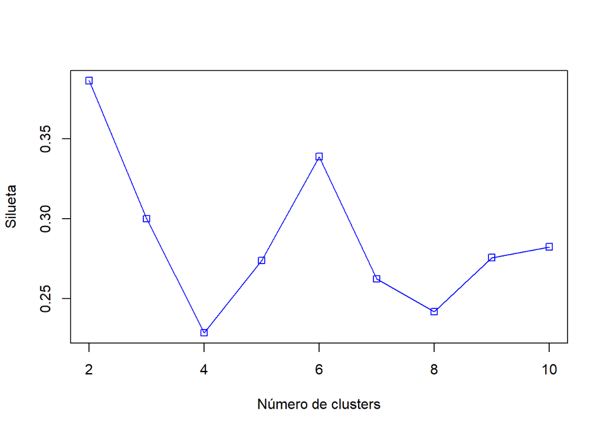

```r
plot(2:10,resultados[2:10],type="o",col="blue",pch=0,xlab="Número de clusters",ylab="Silueta")
```

El método elbow (codo) creará una curva y se seleccionará el valor que se encuentra en el “codo” de esta:

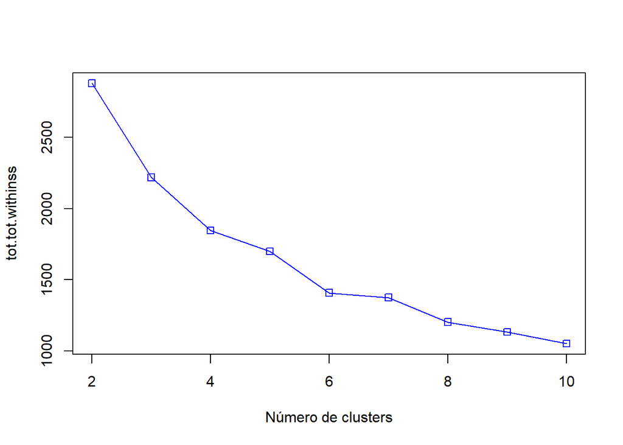

```r
resultados <- rep(0, 10)
for (i in c(2,3,4,5,6,7,8,9,10))
{
  fit           <- kmeans(portugues_2_scale, i)
  resultados[i] <- fit$tot.withinss
}
plot(2:10,resultados[2:10],type="o",col="blue",pch=0,xlab="Número de clusters",ylab="tot.tot.withinss")
```

### 7.1.2 pasamos a la insepección visual:

- Generamos el modelo con 3 clusters

```r
  fit           <- kmeans(portugues_2_scale, 3)
  y_cluster     <- fit$cluster
```

Para visualizar los clústers podemos usar la función clusplot.

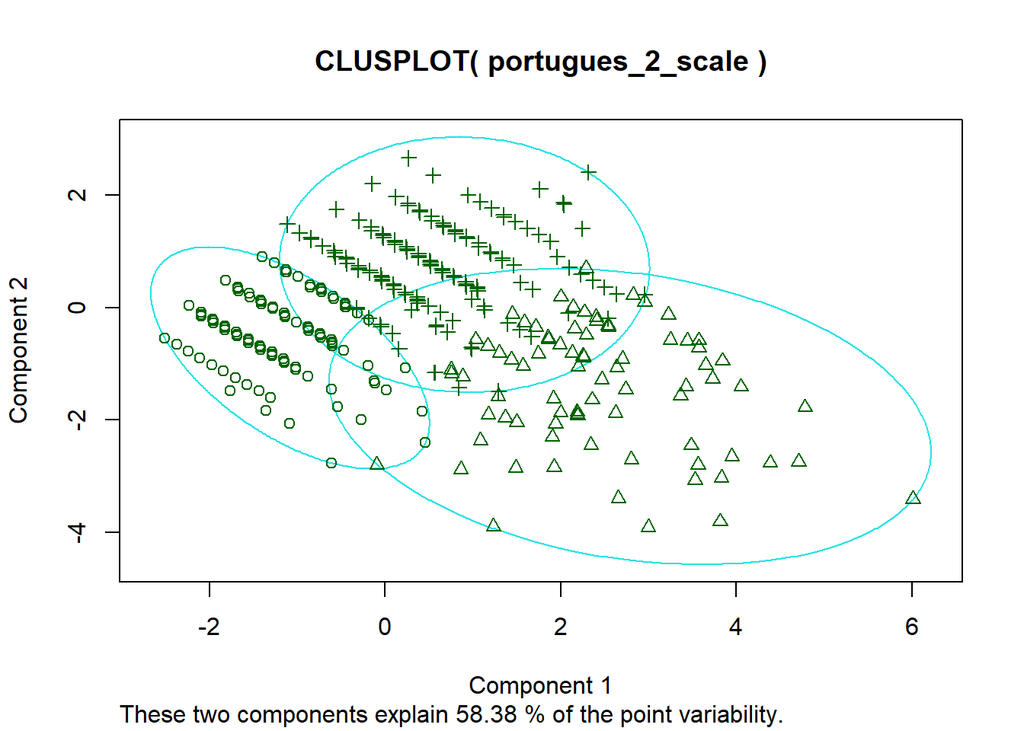

```r
clusplot(portugues_2_scale, y_cluster)
```

- Generamos el modelo con 5 clusters

```r
  fit           <- kmeans(portugues_2_scale, 5)
  y_cluster     <- fit$cluster
```

Para visualizar los clústers podemos usar la función clusplot.

Vemos la agrupación con 5 clústers

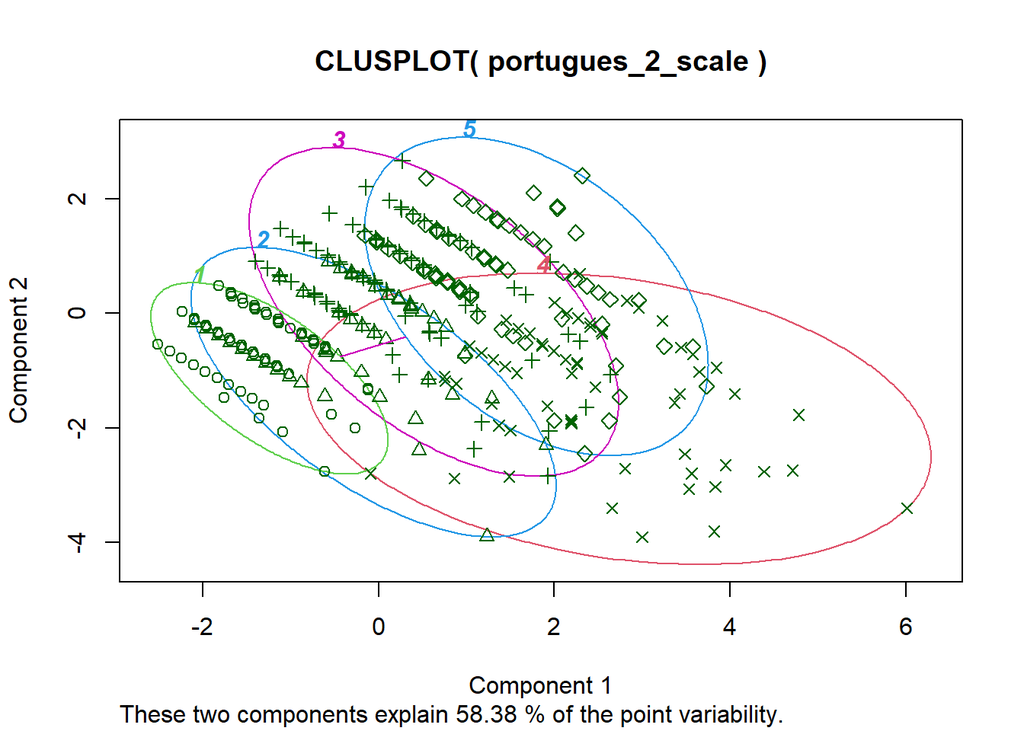

```r
clusplot(portugues_2_scale, y_cluster,color=TRUE, shade=FALSE, labels = 5)
```

- Generamos el modelo con 7 clusters

```r
  fit           <- kmeans(portugues_2_scale, 7)
  y_cluster     <- fit$cluster
```

Para visualizar los clústers podemos usar la función clusplot.

Vemos la agrupación con 7 clústers

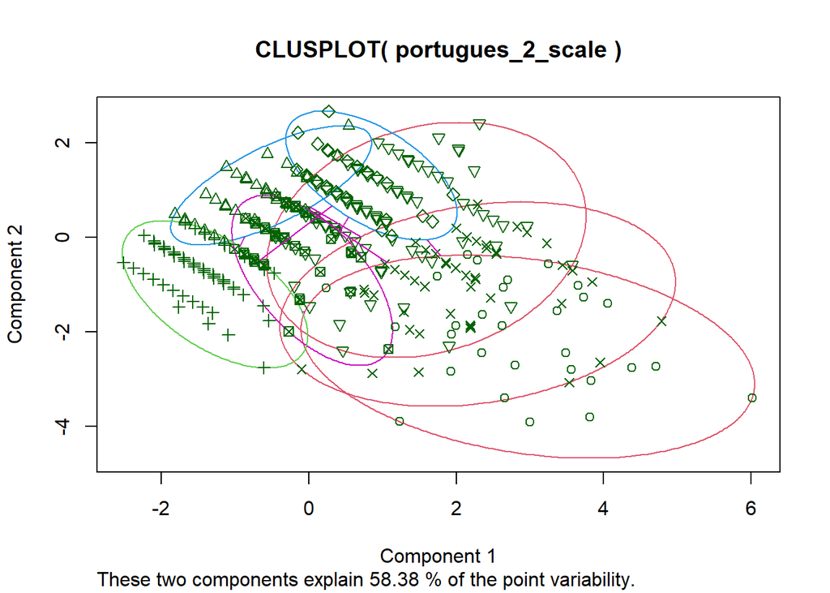

```r
clusplot(portugues_2_scale, y_cluster,color=TRUE, shade=FALSE, labels = 7)
```

### 7.1.3 Conclusiones

Creemos que 7 és un numero demasiado grande ya que se solapan los puntos entre ellos, 3 podría ser el más óptimo pero sinembargo, nos sorprende positivamente la agregación en 5 clusters ya que tanto en la inspección vicual como en el método de Elbow han sido mejores.

Además, si comparamos la elección de las variables, creemos que el modelo conn la elección de variables es mejor:

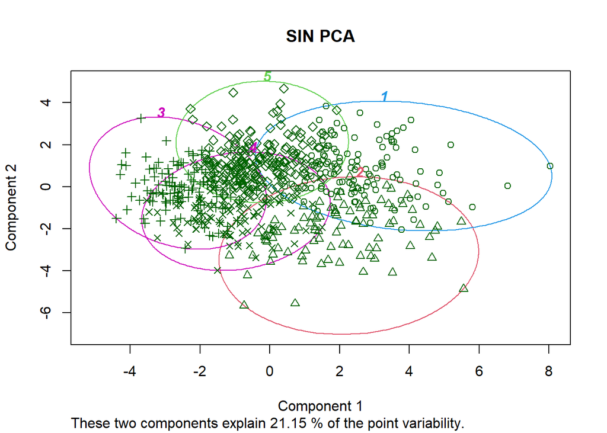

```r
  fit           <- kmeans(portugues_scale, 5)
  y_cluster    <- fit$cluster
  clusplot(main = "SIN PCA" ,portugues_scale, y_cluster,color=TRUE, shade=FALSE, labels = 5)
```

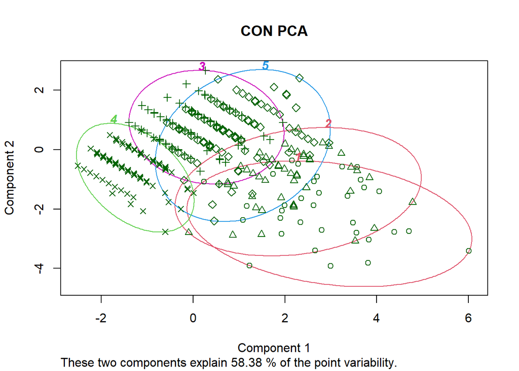

```r
  fit           <- kmeans(portugues_2_scale, 5)
  y_cluster     <- fit$cluster
  clusplot(main = "CON PCA" ,portugues_2_scale, y_cluster,color=TRUE, shade=FALSE, labels = 5)
```

## 7.2 Modelos de agregación con distancias distintas

### 7.2.1 METODO K-MEDOIDS

Este utiliza medianas en vez de medias para limitar la influencia de los outliers.

Creamos la agregacion con 4 clusters

```r
library('factoextra')
```

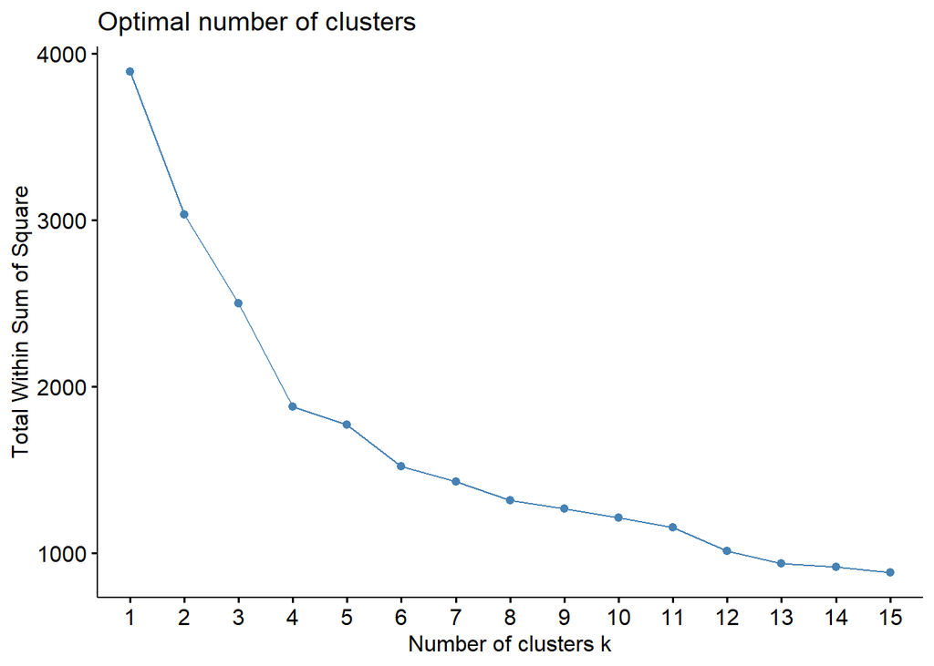

```r
fviz_nbclust(x = portugues_2_scale, FUNcluster = pam, method = "wss", k.max = 15,diss = dist(portugues_2_scale, method ="euclidean" ))
```

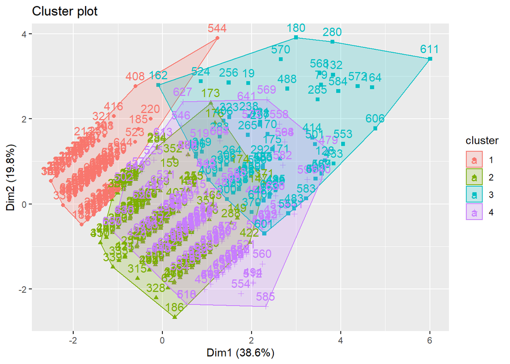

```r
pam.cluster <- pam(portugues_2_scale, 4)

fviz_cluster(pam.cluster, data = portugues_2_scale)
```

Con este nuevo método de agregación, encontramos de nuevo 4 grupos idóneos, que es el número donde la curva empieza a estabilizarse.

Lo comparamos ahora con los datos sin seleccionar

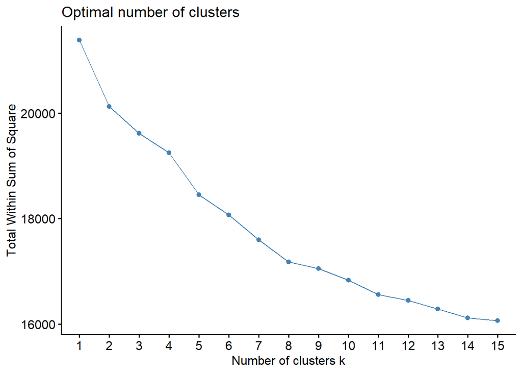

```r
fviz_nbclust(x = portugues_scale, FUNcluster = pam, method = "wss", k.max = 15,
             diss = dist(portugues_scale, method = "euclidean"))
```

Confirmamos pues, que con los datos sin reducir, es difícil de nuevo encontrar el número idóneo de clusters, para indicar que el 8 es el grupo predominante, como en el primer modelo de agregación.

### 7.2.2 Medidas de calidad del modelo K-medois

Podemos testear la calidad del modelo de agregación con el datset de mates, que nos da un numero parecido de clustrers óptimos, 4.

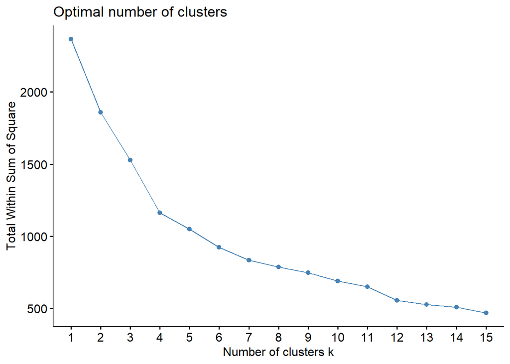

```r
mates_2 <- mates[c(1,7,8,21,30,33)]
mates_2_sale <- scale(mates_2)

fviz_nbclust(x = mates_2_sale, FUNcluster = pam, method = "wss", k.max = 15,
             diss = dist(mates_2_sale, method = "euclidean"))
```

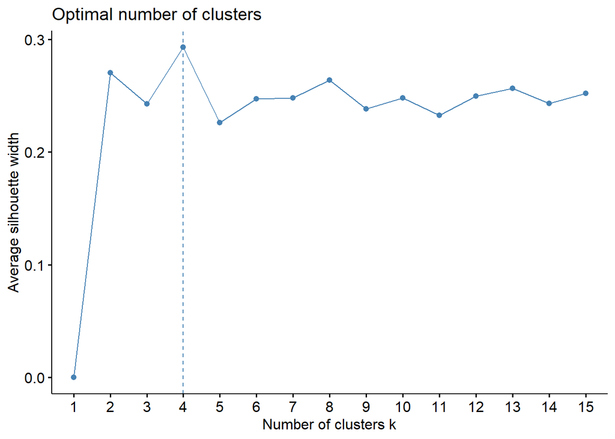

```r
fviz_nbclust(x = portugues_2_scale, FUNcluster = pam, method = "silhouette", k.max = 15,
             diss = dist(portugues_2_scale, method ="euclidean" ))
```

Con Silhouette nos confirma los 4 clusters también.

### 7.2.3 Comparamos los modelos de k-means y k-medoids

Ambos se compararan con el portugues_2_scale, en el que las variables son más adecuadas. - K- means

Generamos el modelo con 4 clusters

```r
  fit           <- kmeans(portugues_2_scale, 4,nstart = 25, )
  y_cluster     <- fit$cluster
```

Vemos la agrupación con 4 clústers de k-means y seguidamente la agrupación de K-medoids tambiñen con 4 clusters

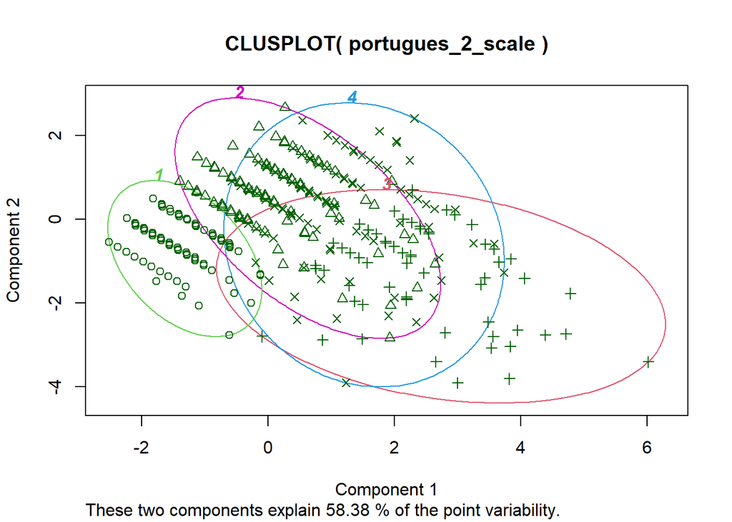

```r
clusplot(portugues_2_scale, y_cluster,color=TRUE, shade=FALSE, labels = 4)
```

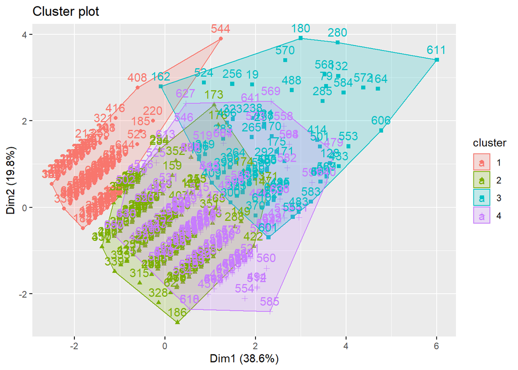

```r
fviz_cluster(pam.cluster, data = portugues_2_scale)
```

Parece que los gráficos son muy similares, pero estan invertidos. Si imaginamos dibujar un eje en el medio, en la parte superior del primer modelo se encuentrean 3 grupos, mientras que en el segundo gráfico estos se encuntran abajo, y al revés con el otros grupo.

## 7.3 Caso de asociación

El objetivo de las reglas de asociación es descubrir información acerca de ellas mismas, es decir, encontrar patrones que se repiten en los dominios de un conjunto de atributos y así poder describir los datos de una manera generalizada, las reglas de asociación trabajan con valores binarios. Nuestro set de datos contiene muchas columnas y creemos que este está enfocado en generar modelos predictivos de las notas/G3, por ende, la realización de reglas de asociación quedaría en segundo plano ya que entendemos que un modelo predictivo será más eficiente.

Para crear reglas de asociación, que podemos usarlas para encontrar los grupos que siguen patrones respecto a las notas, debemos reformular el datset utilizando las variables más significativas. Estas las extraemos del análisis de las componentes principales que hemos visto previamente. Queremos buscar asociaciones con las notas de los alumnos. Es decir, mediante las variables Higher –> failures –> Medu —-> G3, buscaremos los patrones más frecuentes.

## 7.4 modelo de asociación

el siguiente codigo, está inspirado en: https://www.cienciadedatos.net/documentos/43_reglas_de_asociacion

- 0 Paquetes
- 1.Datos

Para proceder con el análisis de las reglas de asociación debemos tenr datos categricos y no numéricos para entender mejor los modelos.

Así pues demos primero categorizar la variable G3, Las notas en portugal van del 0 al 20, 0=> 10 es suspendido, <=10 >14 es aprobado, <=14 >17 es notable, <=17 >19, sobresaliente,<=19 <=20 matricula.

Agrupamos notas

```r
portugues_notas <- cut(portugues$G3, breaks = c(-1,10,14,17,19, 21))
levels(portugues_notas) <- c("suspenso", "aprobado", "notable", "sobresaliente", "matricula")

# cambiamos la variable numerica a codificada en grupos
portugues_2$G3 <- portugues_notas
portugues_2$G3 <- portugues_2$G3


# Seleccionamos las variables para las reglas de asociación:
# Higher --> failures --> Medu ----> G3,
portugues_reglas <- portugues_2[,c(5,2,6)]


# pasamos los numeros a su refernicante
portugues_reglas$higher <- sub(2,"yes",portugues_reglas$higher)
portugues_reglas$higher <- sub(1,"no",portugues_reglas$higher)



portugues_reglas$Medu <- sub(0,"none",portugues_reglas$Medu)

# reducimos los grupos contaremos no tener primaria como none
portugues_reglas$Medu <- sub(1,"none",portugues_reglas$Medu)
portugues_reglas$Medu <- sub(2,"primary education",portugues_reglas$Medu)
portugues_reglas$Medu <- sub(3,"secondary education",portugues_reglas$Medu)
portugues_reglas$Medu <- sub(4,"higher education",portugues_reglas$Medu)



summary(portugues_reglas)
```

```
##     higher              Medu                       G3
##  Length:649         Length:649         suspenso     :197
##  Class :character   Class :character   aprobado     :321
##  Mode  :character   Mode  :character   notable      :114
##                                        sobresaliente: 17
##                                        matricula    :  0
```

### 7.4.1 Adecuació para las reglas

El siguiente código esta sacado de: https://datascienceplus.com/implementing-apriori-algorithm-in-r/

Si - Seleccionamos las variables para las reglas de asociación: Higher –> failures –> Medu —-> G3,*

Rectificación* No usaremos failures ya que creemos que esta demasiado correlacionada con G3

```r
head(portugues_reglas)
```

```
##   higher                Medu       G3
## 1    yes    higher education aprobado
## 2    yes                none aprobado
## 3    yes                none aprobado
## 4    yes    higher education aprobado
## 5    yes secondary education aprobado
## 6    yes    higher education aprobado
```

- Ordenamos el DF

```r
portugues_reglas_ordenado <- portugues_reglas[order(portugues_reglas$higher),]

head(portugues_reglas_ordenado)
```

```
##     higher              Medu       G3
## 79      no primary education suspenso
## 128     no              none aprobado
## 132     no primary education suspenso
## 158     no primary education suspenso
## 162     no  higher education suspenso
## 164     no              none suspenso
```

- Otorgamos forma para los datos repetidos

```r
portugues_reglas_ordenado_i <- ddply(portugues_reglas,c("Medu","higher") # seleccionamos las columnas a codificar, no se incluye G3
                                     ,function(portugues_reglas_ordenado)paste(portugues_reglas_ordenado$G3,           collapse = ","))



head(portugues_reglas_ordenado_i,100)
```

[output not shown]

```r
write.csv(portugues_reglas_ordenado_i,"ItemList.csv", quote = FALSE, row.names = TRUE)
```

- Reglas de asociación

```r
txn = read.transactions(file="ItemList.csv", rm.duplicates= TRUE, format="basket",sep=",",cols=1,header = TRUE)
```

```
## distribution of transactions with duplicates:
## items
##  10  25  26 117 123 155 169
##   1   1   1   1   1   1   1
```

eliminamos las “quotes”

```r
txn@itemInfo$labels <- gsub("\"","",txn@itemInfo$labels)
```

aplicamos las reglas

```r
notas_rules <- apriori(txn,parameter = list(sup = 0.01, conf = 0.5,target="rules"));
```

```
## Apriori
##
## Parameter specification:
##  confidence minval smax arem  aval originalSupport maxtime support minlen
##         0.5    0.1    1 none FALSE            TRUE       5    0.01      1
##  maxlen target  ext
##      10  rules TRUE
##
## Algorithmic control:
##  filter tree heap memopt load sort verbose
##     0.1 TRUE TRUE  FALSE TRUE    2    TRUE
##
## Absolute minimum support count: 0
##
## set item appearances ...[0 item(s)] done [0.00s].
## set transactions ...[10 item(s), 8 transaction(s)] done [0.00s].
## sorting and recoding items ... [10 item(s)] done [0.00s].
## creating transaction tree ... done [0.00s].
## checking subsets of size 1 2 3 4 5 6 done [0.00s].
## writing ... [433 rule(s)] done [0.00s].
## creating S4 object  ... done [0.00s].
```

```r
if(sessionInfo()['basePkgs']=="tm" | sessionInfo()['otherPkgs']=="tm"){
    detach(package:tm, unload=TRUE)
}
df_notas <- as(notas_rules,"data.frame")
```

Plot reglas

```
## To reduce overplotting, jitter is added! Use jitter = 0 to prevent jitter.
```

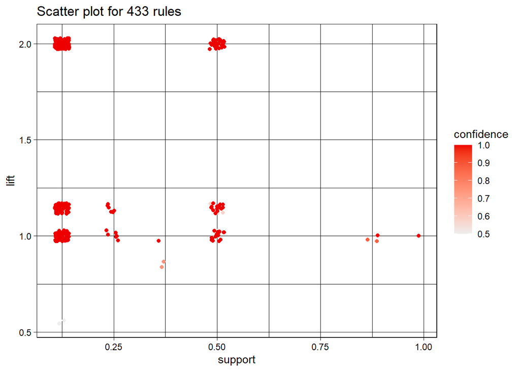

```r
plot(notas_rules,measure=c("support","lift"),shading="confidence")
```

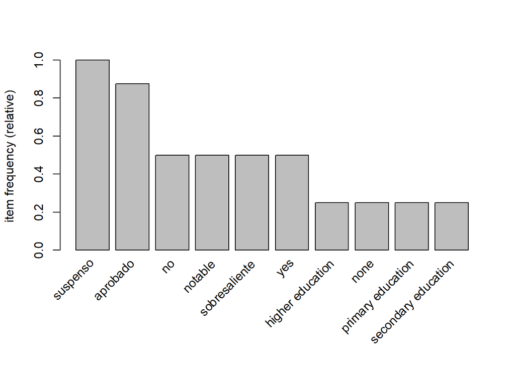

```r
itemFrequencyPlot(txn, topN = 10)
```

```r
inspect(head(notas_rules,50))
```

```
##      lhs                      rhs             support confidence coverage
## [1]  {}                    => {no}            0.500   0.5000000  1.000
## [2]  {}                    => {notable}       0.500   0.5000000  1.000
## [3]  {}                    => {sobresaliente} 0.500   0.5000000  1.000
## [4]  {}                    => {yes}           0.500   0.5000000  1.000
## [5]  {}                    => {aprobado}      0.875   0.8750000  1.000
## [6]  {}                    => {suspenso}      1.000   1.0000000  1.000
## [7]  {higher education}    => {no}            0.125   0.5000000  0.250
## [8]  {higher education}    => {notable}       0.125   0.5000000  0.250
## [9]  {higher education}    => {sobresaliente} 0.125   0.5000000  0.250
## [10] {higher education}    => {yes}           0.125   0.5000000  0.250
## [11] {higher education}    => {aprobado}      0.125   0.5000000  0.250
## [12] {higher education}    => {suspenso}      0.250   1.0000000  0.250
## [13] {none}                => {no}            0.125   0.5000000  0.250
## [14] {none}                => {notable}       0.125   0.5000000  0.250
```

[output cut: 87 more lines]

Enocntramos que existe un grupo de reglas con el lift de 2, lo que indica que las reglas ya tienen algo de entidad.

Veamos la reglas con mayor lift:

```r
inspect(head(sort(notas_rules, by = "lift"), 20))
```

```
##      lhs                                 rhs             support confidence
## [1]  {notable}                        => {sobresaliente} 0.500   1
## [2]  {sobresaliente}                  => {notable}       0.500   1
## [3]  {notable}                        => {yes}           0.500   1
## [4]  {yes}                            => {notable}       0.500   1
## [5]  {sobresaliente}                  => {yes}           0.500   1
## [6]  {yes}                            => {sobresaliente} 0.500   1
## [7]  {higher education,notable}       => {sobresaliente} 0.125   1
## [8]  {higher education,sobresaliente} => {notable}       0.125   1
## [9]  {higher education,notable}       => {yes}           0.125   1
## [10] {higher education,yes}           => {notable}       0.125   1
## [11] {aprobado,higher education}      => {notable}       0.125   1
## [12] {higher education,sobresaliente} => {yes}           0.125   1
## [13] {higher education,yes}           => {sobresaliente} 0.125   1
## [14] {aprobado,higher education}      => {sobresaliente} 0.125   1
```

[output cut: 27 more lines]

Destacamosque independientemente de los errores, en los que aparecen notas donde no debería, que: Su madre tiene estudios universitarios y sus hijos quieren ir a la universidad, Sacan notables y excelentes. {higher education,yes => {notable} 0.125 1 0.125  
{higher education,yes} => {sobresaliente}

## 7.5 Modelo de arbol de decisión:

Trabajaremos con la matriz numérica, a diferencia del punto anterior.

### 7.5.1 Creamos los datos de testeo

```r
set.seed(1)
testeo_portugues <- portugues_2[sample(nrow(portugues_2)),]

# G3 está en la última columna
# varaiable dependiente Y
y <- testeo_portugues[,6]
x <- testeo_portugues[,-6]

nrow(testeo_portugues)
```

```
## [1] 649
```

-2. Testeos entrenamiento

Creamos las muestras de entrenamiento y prueba, una proporción de 2/3 y 1/3 respectivamente

```r
split_prop <- 3

indexes = sample(1:nrow(testeo_portugues), size=floor(((split_prop-1)/split_prop)*nrow(testeo_portugues)))



trainx<-x[indexes,]
trainy<-y[indexes]
testx<-x[-indexes,]
testy<-y[-indexes]
```

- 2.1 comprobamos proporción

```r
prop.table(table(trainy))
```

```
## trainy
##      suspenso      aprobado       notable sobresaliente     matricula
##    0.30555556    0.49305556    0.17592593    0.02546296    0.00000000
```

```r
prop.table(table(testy))
```

```
## testy
##      suspenso      aprobado       notable sobresaliente     matricula
##    0.29953917    0.49769585    0.17511521    0.02764977    0.00000000
```

Vemos que las proporciones son correctas en ambos datos. Estamos listos para crear el modelo de asociación

Reglas del arbol sin opciones de poda:

```r
trainy = as.factor(trainy)
modelo_sin_poda <- C50::C5.0(trainx, trainy, rules=TRUE, control = C50::C5.0Control(noGlobalPruning = TRUE))
summary(modelo_sin_poda)
```

```
##
## Call:
## C5.0.default(x = trainx, y = trainy, rules = TRUE, control
##  = C50::C5.0Control(noGlobalPruning = TRUE))
##
##
## C5.0 [Release 2.07 GPL Edition]      Tue Oct 18 14:05:28 2022
## -------------------------------
##
## Class specified by attribute `outcome'
##
## Read 432 cases (6 attributes) from undefined.data
##
## Rules:
##
## Rule 1: (64/9, lift 2.8)
##  Medu <= 3
##  failures > 0
##  ->  class suspenso  [0.848]
##
## Rule 2: (43/11, lift 2.4)
##  higher <= 1
##  ->  class suspenso  [0.733]
##
## Rule 3: (153/77, lift 1.6)
##  school > 1
##  ->  class suspenso  [0.497]
##
## Rule 4: (152/56, lift 1.3)
##  Medu <= 3
##  Fedu > 1
##  failures <= 0
##  higher > 1
##  ->  class aprobado  [0.630]
##
## Rule 5: (236/92, lift 1.2)
##  school <= 1
##  failures <= 0
##  higher > 1
##  ->  class aprobado  [0.609]
```

[output cut: 36 more lines]

```
##       4    72                      (c): class notable
##       2     6           3          (d): class sobresaliente
##                                    (e): class matricula
##
##
##  Attribute usage:
##
##   91.20% school
##   83.80% failures
##   78.01% higher
##   71.30% Medu
##   56.02% Fedu
##
##
## Time: 0.0 secs
```

El modelo ha generado un 37.0% de errores en la predicción de G3. No es un resultado notable pero es bastante decente. Destacamos las dos primeras reglas.

Rule 1: (64/9, lift 2.8) Medu <= 3 failures > 0 -> class suspenso [0.848]

Rule 2: (43/11, lift 2.4) higher <= 1 -> class suspenso [0.733]

- Reglas del arbol con opciones de poda:

```r
trainy = as.factor(trainy)
model_con_poda <- C50::C5.0(trainx, trainy, rules=TRUE, control = C50::C5.0Control(noGlobalPruning = FALSE))
summary(model_con_poda)
```

```
##
## Call:
## C5.0.default(x = trainx, y = trainy, rules = TRUE, control
##  = C50::C5.0Control(noGlobalPruning = FALSE))
##
##
## C5.0 [Release 2.07 GPL Edition]      Tue Oct 18 14:05:28 2022
## -------------------------------
##
## Class specified by attribute `outcome'
##
## Read 432 cases (6 attributes) from undefined.data
##
## Rules:
##
## Rule 1: (71/14, lift 2.6)
##  failures > 0
##  ->  class suspenso  [0.795]
##
## Rule 2: (43/11, lift 2.4)
##  higher <= 1
##  ->  class suspenso  [0.733]
##
## Rule 3: (61/24, lift 2.0)
##  school > 1
##  Fedu <= 1
##  ->  class suspenso  [0.603]
##
## Rule 4: (361/160, lift 1.1)
##  failures <= 0
##  ->  class aprobado  [0.556]
##
## Default class: aprobado
##
##
## Evaluation on training data (432 cases):
##
##          Rules
##    ----------------
##      No      Errors
##
##       4  166(38.4%)   <<
##
##
##     (a)   (b)   (c)   (d)   (e)    <-classified as
##    ----  ----  ----  ----  ----
##      90    42                      (a): class suspenso
##      37   176                      (b): class aprobado
##       5    71                      (c): class notable
##       2     9                      (d): class sobresaliente
##                                    (e): class matricula
##
##
##  Attribute usage:
##
##  100.00% failures
##   14.12% school
##   14.12% Fedu
##    9.95% higher
##
##
## Time: 0.0 secs
```

El modelo clasifica erronamente en un 38.4% de los casos. Destacamos la primera y la segunda regla, que como vemos repite el segundo caso con la misma puntuación: Rule 1: (71/14, lift 2.6) failures > 0 -> class suspenso [0.795]

Rule 2: (43/11, lift 2.4) higher <= 1 -> class suspenso [0.733]

Remarcamos los estudiantes que ya han suspendido antes (failures > 0), luego tienen más probabilidades de suspender G3.

```r
# modelo_con_poda <- C50::C5.0(trainx, trainy, rules=FALSE, control = C50::C5.0Control(noGlobalPruning = FALSE))
# plot(modelo_sin_poda)
```

### 7.5.2 Matriz de confusión

```r
predicted_model_con_poda <- predict( model_con_poda, testx, type="class" )


mat_conf<-table(testy,Predicted=predicted_model_con_poda)
mat_conf
```

```
##                Predicted
## testy           suspenso aprobado notable sobresaliente matricula
##   suspenso            41       24       0             0         0
##   aprobado            15       93       0             0         0
##   notable              0       38       0             0         0
##   sobresaliente        0        6       0             0         0
##   matricula            0        0       0             0         0
```

- Evaluación

Hemos podido ver que la eficiencia con poda es unpoco pero que sin poda.Sin embargo, la comprensibilidad es mejor con poda.

Las reglas que hemos obtenido son: Rule 1: (71/14, lift 2.6) failures > 0 -> class suspenso [0.795]

Rule 2: (43/11, lift 2.4) higher <= 1 -> class suspenso [0.733]

Rule 1: (64/9, lift 2.8) Medu <= 3 failures > 0 -> class suspenso [0.848]

##Boosting

para las técnicas de boosting, obtenemos información de los siguientes links.

https://www.cienciadedatos.net/documentos/33_arboles_decision_random_forest_gradient_boosting_c50#C50 y

https://rubenfcasal.github.io/aprendizaje_estadistico/boosting-en-r.html

La capacidad predictiva de los modelos basados en un único árbol es bastante inferior a la conseguida con otros modelos. Esto es debido a su tendencia al overfitting y alta varianza.

Creamos el primer modelo con poda y con boosting, earlyStopping = FALSE

```r
trainy = as.factor(trainy)
model_con_poda_boost <- C50::C5.0(trainx, trainy, rules=TRUE, control = C50::C5.0Control(noGlobalPruning = FALSE, earlyStopping = FALSE ))
summary(model_con_poda_boost)
```

```
##
## Call:
## C5.0.default(x = trainx, y = trainy, rules = TRUE, control
##  = C50::C5.0Control(noGlobalPruning = FALSE, earlyStopping = FALSE))
##
##
## C5.0 [Release 2.07 GPL Edition]      Tue Oct 18 14:05:28 2022
## -------------------------------
##
## Class specified by attribute `outcome'
##
## Read 432 cases (6 attributes) from undefined.data
##
## Rules:
##
## Rule 1: (71/14, lift 2.6)
##  failures > 0
##  ->  class suspenso  [0.795]
##
## Rule 2: (43/11, lift 2.4)
##  higher <= 1
##  ->  class suspenso  [0.733]
##
## Rule 3: (61/24, lift 2.0)
##  school > 1
##  Fedu <= 1
##  ->  class suspenso  [0.603]
##
## Rule 4: (361/160, lift 1.1)
##  failures <= 0
##  ->  class aprobado  [0.556]
##
## Default class: aprobado
##
##
## Evaluation on training data (432 cases):
##
##          Rules
##    ----------------
##      No      Errors
##
##       4  166(38.4%)   <<
##
##
##     (a)   (b)   (c)   (d)   (e)    <-classified as
##    ----  ----  ----  ----  ----
##      90    42                      (a): class suspenso
##      37   176                      (b): class aprobado
##       5    71                      (c): class notable
##       2     9                      (d): class sobresaliente
##                                    (e): class matricula
##
##
##  Attribute usage:
##
##  100.00% failures
##   14.12% school
##   14.12% Fedu
##    9.95% higher
##
##
## Time: 0.0 secs
```

No se aprecian diferencias así que probaremos otra técnica de boosting

```r
tree_boost <- C50::C5.0(x = trainx, y = trainy, trials = 3, rules = TRUE)
summary(tree_boost)
```

```
##
## Call:
## C5.0.default(x = trainx, y = trainy, trials = 3, rules = TRUE)
##
##
## C5.0 [Release 2.07 GPL Edition]      Tue Oct 18 14:05:28 2022
## -------------------------------
##
## Class specified by attribute `outcome'
##
## Read 432 cases (6 attributes) from undefined.data
##
## -----  Trial 0:  -----
##
## Rules:
##
## Rule 0/1: (71/14, lift 2.6)
##  failures > 0
##  ->  class suspenso  [0.795]
##
## Rule 0/2: (43/11, lift 2.4)
##  higher <= 1
##  ->  class suspenso  [0.733]
##
## Rule 0/3: (61/24, lift 2.0)
##  school > 1
##  Fedu <= 1
##  ->  class suspenso  [0.603]
##
## Rule 0/4: (361/160, lift 1.1)
##  failures <= 0
##  ->  class aprobado  [0.556]
##
## Default class: aprobado
##
## -----  Trial 1:  -----
##
## Rules:
##
## Rule 1/1: (67.8/16.1, lift 2.5)
```

[output cut: 53 more lines]

```
##      32   181                      (b): class aprobado
##       5    71                      (c): class notable
##       2     9                      (d): class sobresaliente
##                                    (e): class matricula
##
##
##  Attribute usage:
##
##  100.00% failures
##   92.36% school
##   76.16% Fedu
##    9.95% higher
##
##
## Time: 0.0 secs
```

```r
predict(tree_boost, newdata = testx[1:3,], type = "prob")
```

```
##     suspenso aprobado notable sobresaliente matricula
## 509        1        0       0             0         0
## 299        0        1       0             0         0
## 591        1        0       0             0         0
```

# 8 Conclusiones y posibles limitaciones

Preparando el modelo nos hemos tenido que plantear que datasrt utilizábamos. Debido a que venían dos datasets la duda era que hacer con ellos dos, nos han surgido muchas preguntas sobre ello, cómo: ¿Si mezclamos ambos datasets estará el colegio X sobre representado? O ¿estarán sobre representados los alumnos y sus atributos? ¿Y si los juntamos y eliminamos ciertos registros?

Estas dudas, mediante la prueba y el error nos han dado ciertos resultados, hemos decidido trabajar finalmente solo sobre el datset de portuguese ya que este tenia solo alumnos no repetidos, conservaba los atributos al completo y no se corría el riesgo de overfitting.

Las limitaciones para el modelo no supervisado han sido primordialmente pocas. Los datos contenían demasiadas variables, pero el previo estudio de las componentes principales nos ha ayudado para determinar las que más variabilidad explicaban. Sin embargo, justo al final de este trabajo nos hemos dado cuenta de que el uso de “failure”, que es una variable altamente correlacionada con G3 podía estar sesgando los datos ya que al basarse en el historial podría darse el caso de menospreciar las variables que de verdad determinan la agregación y la clasificación a posteriori en el modelo supervisado.

Además, las limitaciones para el método supervisado han sido en cuanto a la inserción de las variables como tabla binaria, que finalmente no ha sido del todo adecuado, y pese a que se han obtenido reglas decentes, deberíamos haber impedido que las reglas de asociación combinaran dos veces o más notas, es decir notable  excelente, ya que esto demuestra que aun y estando generando todas las reglas de igual manera, el cómputo de las mismas ha sido mucho más ineficiente